# Brownlows Bets

Kelly Patrizio

Nov. 12, 2020

# 1 Introduction

At the first day of class there are 35 students in Math Statistics class and professor Brownlow always proposes this bet to his students "I will wager $2 to your bet of $1 that at least two people in today’s class have the same birthday. He tells me he has made that bet 637 times so far. Where do you think his profits are? Discuss this in a markdown document

There are 3 questions and there should be at least 3 separate commits, at least one dealing with each of the 3 questions. 1. What are the fair odds for a bet on matching birthdays in a 35 person class. 2. For what size class is a 2:1 odds bet fair. 3. How much money would Brownlow be expected to end up with if the bets went as described.

# 2 Methods

We will solve this problem by re-sampling. We will set up days of the year, take a random sample of 35, and see if two or more have the same birthday.

# 3 Sample data

```r
daysYEAR=1:365
```

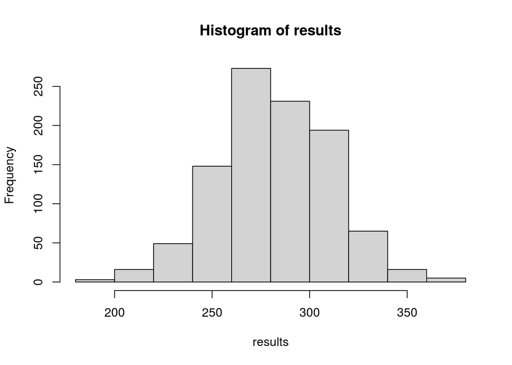

```r
results=vector("numeric")
for(j in 1:1000){
bank=0
for(i in 1:637){
  class=sample(daysYEAR,35,replace=TRUE)
  n=length(unique(class))
if(n==35)bank=bank-2
  else bank=bank+1
}
results[j]=bank
}
hist(results)
```

# 4 Answers to the following three questions

### 4.0.1 1. What are the fair odds for a bet on matching birthdays in a 35 person class.

```
                     # Fair Odds Payout
```

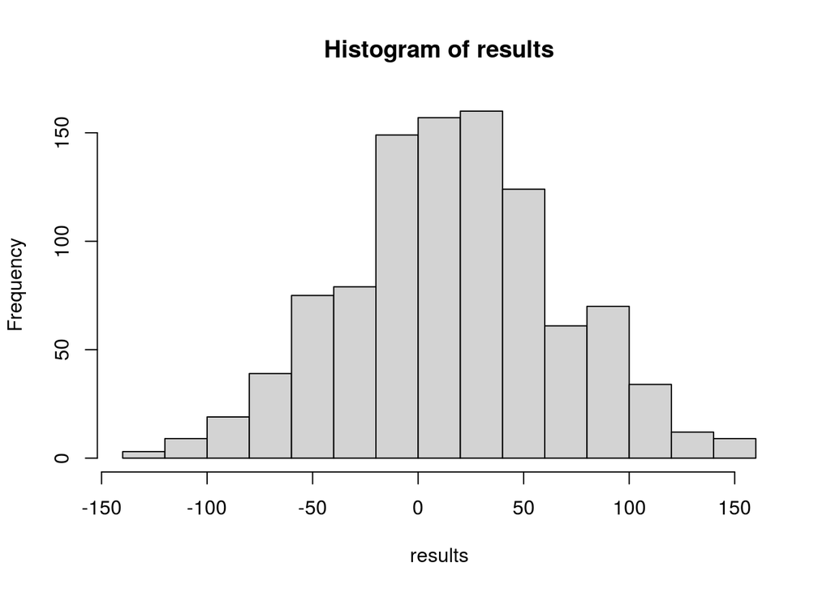

```r
results=vector("numeric")
for(j in 1:1000){
bank=0
for(i in 1:637){
  class=sample(daysYEAR,35,replace=TRUE)
  n=length(unique(class))
if(n==35)bank=bank-4.25
  else bank=bank+1
}
results[j]=bank
}

hist(results)
```

The amount of money Dr. J would have to pay out to be a fair odds bet, would be…$4.25.

### 4.0.2 2. For what size class is a 2:1 odds bet fair.

```
                   # number of students for a fair bet
```

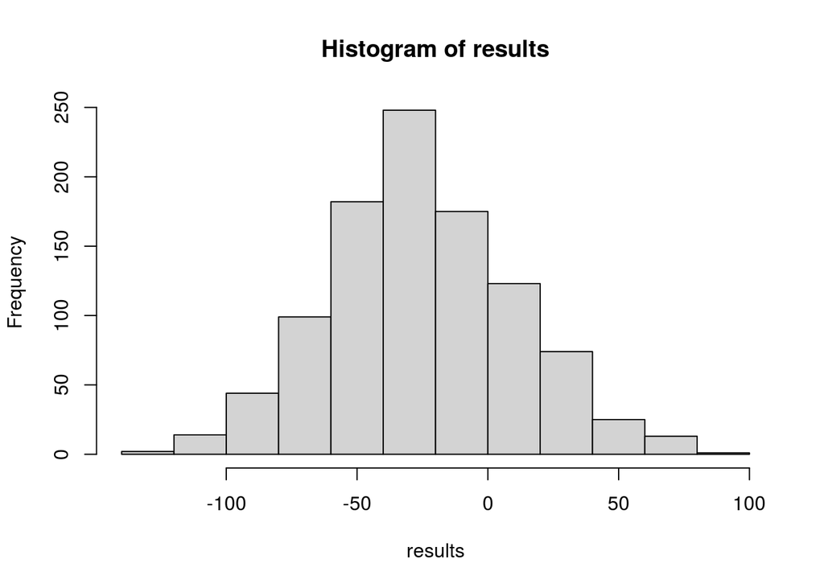

```r
results=vector("numeric")
for(j in 1:1000){
bank=0
for(i in 1:637){
  class=sample(daysYEAR,28,replace=TRUE)
  n=length(unique(class))
if(n==28)bank=bank-2
  else bank=bank+1
}
results[j]=bank
}

hist(results)
```

### 4.0.3 3. How much money would Brownlow be expected to end up with if the bets went as described.

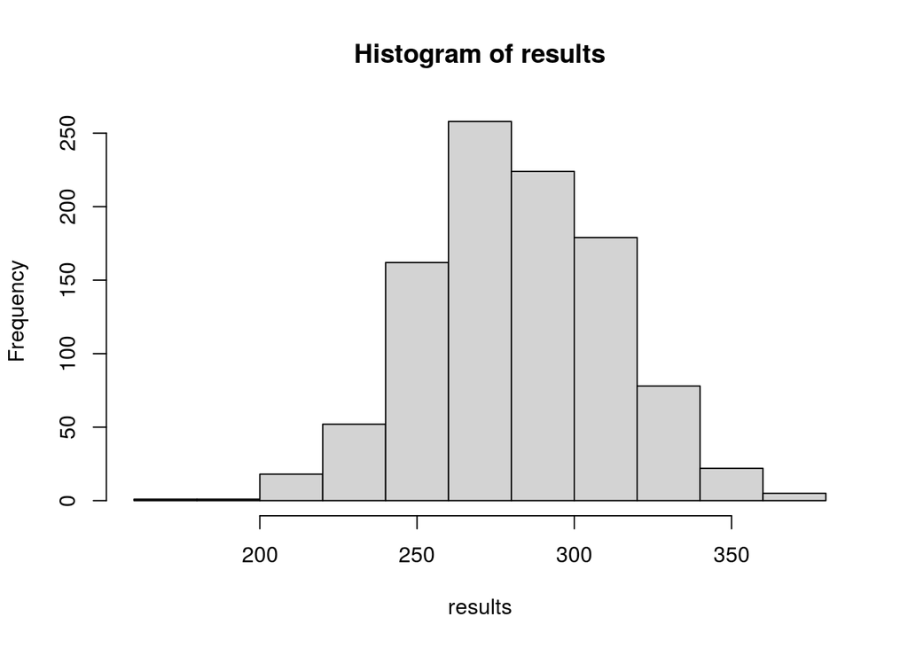

```r
results=vector("numeric")
for(j in 1:1000){
bank=0
for(i in 1:637){
  class=sample(daysYEAR,35,replace=TRUE)
  n=length(unique(class))
if(n==35)bank=bank-2
  else bank=bank+1
}
results[j]=bank
}
sortRESULTS=sort(results)
lcl=sortRESULTS[25]
ucl=sortRESULTS[975]

hist(results)
```